# Visualize Super Tuesday

Devraj Kori

3/4/2020

## What actually happened on Super Tuesday?

I’ve noticed that the press coverage of Super Tuesday of the 2020 Democratic primary seemed to focus almost exclusively on who “won” specific states. This is a familiar format of election coverage for most of us as its how we generally hear national results for general elections.

In the general election for president, almost every state is winner-take-all, meaning whoever receives a plurality of the vote in that state claims all of the electors from that state. Unlike the general, in the Democratic primary, almost every state divides up its “delegates” sort of proportionally among all of the candidates who hit a certain threshold.

That means that presenting election results in terms of state wins can be misleading for a couple reasons: 1. It treats states where a single candidate gets all of the delegates, and states where delegates are equally split between two or more candidates exactly the same. 2. Because most of us don’t know the relative populations of all 50 states off the top of our heads, it makes it hard to compare candidate A’s strongest performing states with Candidate B’s.

## Are these results surprising?

The big twist in the days leading up to Super Tuesday were two major candidates, Amy Klobuchar and Pete Buttigieg, both dropping out and endorsing Joe Biden. The results seemed to show that, perhaps unsurprisingly, Biden drastically outperformed the [lead-up polling](https://fivethirtyeight.com/features/what-makes-our-new-2020-democratic-primary-polling-averages-different/). Assuming the polling wasn’t systematically wrong, this was probably due to a combination of Pete and Amy supporters voting for Biden because of their endorsements, and undecided voters choosing him as the standardbearer for the moderate wing of the party.

The fact that the narrative around Bernie’s performance has been mostly doom-and-gloom has at least a little to do with this same issue of “winning” states. Sanders was projected to win many Super Tuesday states, but was never really polling all that high in any of them, just high enough to keep his head above the rest of the pack. When candidates dropped out and their share mostly redistributed between those who remained, that lead shrunk.

[output not shown]

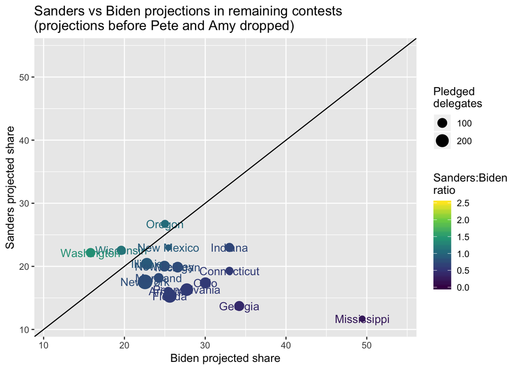

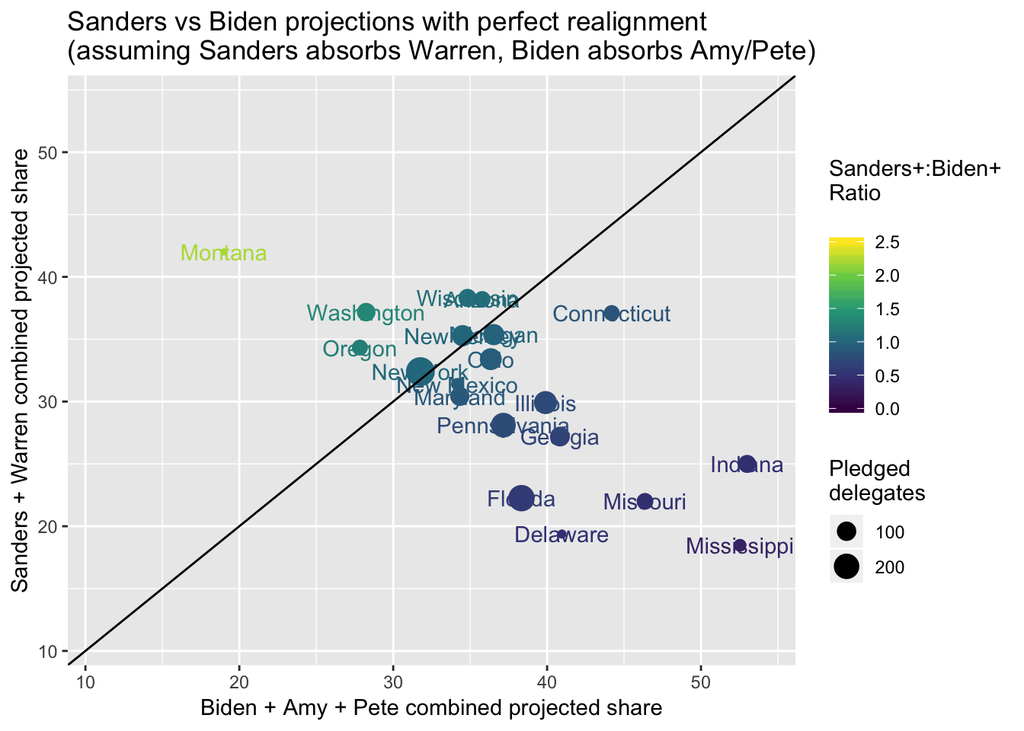

(Source: 538 Polling Averages. Excludes the following contests where polling was unavailable: LA, KY, PR, KS, NE, WV, RI, HI, ID, DC, SD, AK, ND, DA, GU, VI, MP.)